# Methods & Benchmarks

- Show All Code
- Hide All Code
- View Source

Every model in uncertainty_flow, when to use it, how they compare, and how to run your own benchmarks

Published

July 14, 2026

# Methods & Benchmarks

This notebook is a **model selection guide** backed by benchmark data.

1. **Model Reference** — every model, its method, coverage guarantee, and use case
2. **Key Findings** — data-driven insights from real benchmarks
3. **Benchmark Architecture** — Module / Interface / Seam layout
4. **Running Benchmarks** — Python API and CLI
5. **Visual Comparison** — coverage vs sharpness across datasets

## Benchmark Architecture (Module / Interface / Seam)

The benchmarking package uses explicit module seams:

- **Orchestration Modules**: `BenchmarkCoordinator` and `ModelMatrixCoordinator`
- **Model Provider Interface Seam**: `BenchmarkModelProvider` in `providers.py`
- **Dataset Adapter Seam**: `load_dataset` in `datasets.py`
- **Tuning Adapter Seam**: `auto_tune_model` in `tuning.py`
- **Evaluation Adapter Seam**: executable metric registrations in `registry.py`
- **Result Contract**: `PipelineRunResult` and `ModelExecutionResult` in `contracts/results.py`

Pipeline lifecycle per run:

1. Resolve `RunRequest` and load through a registered dataset adapter.
2. Materialize Bronze, Silver, and Gold lineage in staging.
3. Fit registered providers and evaluate registered metrics.
4. Verify and promote the final Platinum manifest last.

## Model Reference

| Model | Method | Coverage | Speed | Best For |
| --- | --- | --- | --- | --- |
| `ConformalRegressor` | Split conformal | Guaranteed (finite-sample) | Fast | Tabular regression, new users |
| `ConformalForecaster` | Conformal + time features | Guaranteed (exchangeable) | Fast | Time series, any sklearn regressor |
| `QuantileForestForecaster` | Quantile regression forest | Empirical | Medium | Sharp intervals, feature importance |
| `DeepQuantileNet` | sklearn MLP quantile net | Empirical | Medium | Nonlinear patterns, no conformal |
| `ConformalClassifier` | APS (Romano et al. 2020) | Guaranteed | Fast | Multi-class classification |
| `AdaptiveConformalForecaster` | Gibbs & Candes ACI | Adaptive | Fast | Streaming / distribution shift |
| `EnsembleBootstrapPI` | EnbPI (Xu & Xie 2021) | Empirical | Slow | Time series ensemble |
| `ConformalRiskControl` | Risk-controlled conformal | On risk metric | Fast | Cost-sensitive decisions |

## Benchmark Findings

```python
import polars as pl
import numpy as np
import matplotlib.pyplot as plt
```

```python
raw = pl.read_csv("../docs/benchmarks/comparison_table.csv", try_parse_dates=False)
print(f"Datasets: {raw['dataset'].unique().to_list()}")
print(f"Models: {raw['model'].unique().to_list()}")
print(f"Total rows: {len(raw)}")
```

```
Datasets: ['weather', 'electricity', 'exchange_rate']
Models: ['deep-quantile', 'random-forest', 'gradient-boosting', 'bayesian-quantile', 'linear-regression', 'naive-forecast', 'quantile-forest', 'conformal-forecaster', 'moving-average', 'ridge-regression', 'conformal-regressor', 'deep-quantile-torch']
Total rows: 36
```

### Finding 1: Coverage-Accuracy Tradeoff

```python
summary = raw.group_by("model").agg([
    pl.col("coverage_90").mean().alias("mean_coverage_90"),
    pl.col("winkler_90").mean().alias("mean_winkler_90"),
    pl.col("crps").mean().alias("mean_crps"),
    pl.col("mae").mean().alias("mean_mae"),
    pl.col("train_time_sec").mean().alias("mean_train_time"),
]).sort("mean_coverage_90", descending=True)
summary
```

shape: (12, 6)

| model str | mean_coverage_90 f64 | mean_winkler_90 f64 | mean_crps f64 | mean_mae f64 | mean_train_time f64 |
| --- | --- | --- | --- | --- | --- |
| "deep-quantile-torch" | 0.928 | 264.454633 | 30.189867 | 41.1705 | 1.522333 |
| "deep-quantile" | 0.899667 | 264.1989 | 34.775633 | 47.676967 | 1.996333 |
| "conformal-forecaster" | 0.8644 | 134.0139 | 15.728933 | 20.834967 | 0.317667 |
| "quantile-forest" | 0.835 | 107.486333 | 13.209467 | 17.191233 | 0.468667 |
| "linear-regression" | 0.737333 | 179.058267 | 18.8176 | 21.496133 | 0.019 |
| … | … | … | … | … | … |
| "conformal-regressor" | 0.720333 | 151.7409 | 17.7965 | 23.6311 | 0.324667 |
| "random-forest" | 0.713 | 134.412367 | 12.792667 | 14.168767 | 0.102333 |
| "naive-forecast" | 0.362333 | 580.662633 | 72.5927 | 100.222867 | 0.000333 |
| "moving-average" | 0.303 | 921.0943 | 89.214533 | 115.2421 | 0.002333 |
| "bayesian-quantile" | 0.000667 | 8.6816e6 | 438069.180267 | 439022.567433 | 11.059 |

### Finding 2: Coverage vs Sharpness by Dataset

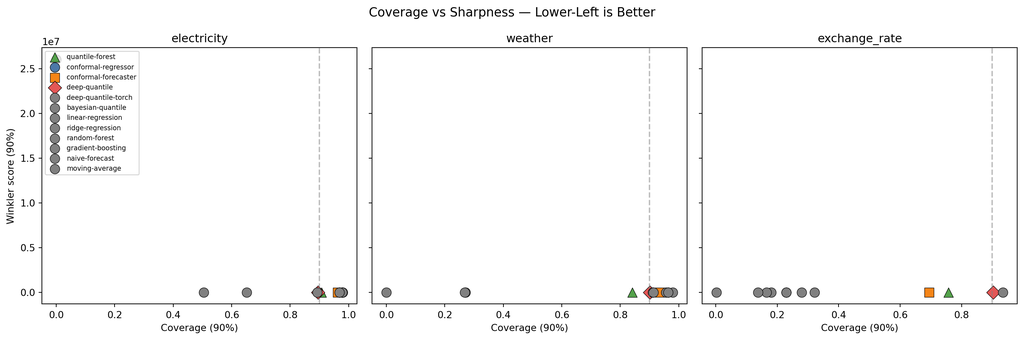

```python
datasets = raw["dataset"].unique().to_list()
n_ds = len(datasets)

fig, axes = plt.subplots(1, n_ds, figsize=(5 * n_ds, 5), sharey=True)
if n_ds == 1:
    axes = [axes]

markers = {"conformal-regressor": "o", "conformal-forecaster": "s",
           "quantile-forest": "^", "deep-quantile": "D"}
colors_map = {"conformal-regressor": "#4C78A8", "conformal-forecaster": "#F58518",
              "quantile-forest": "#54A24B", "deep-quantile": "#E45756"}

for ax, ds in zip(axes, datasets):
    subset = raw.filter(pl.col("dataset") == ds)
    for row in subset.iter_rows(named=True):
        m = row["model"]
        ax.scatter(
            row["coverage_90"], row["winkler_90"],
            marker=markers.get(m, "o"),
            c=colors_map.get(m, "gray"),
            s=100, label=m if ds == datasets[0] else None,
            edgecolors="black", linewidth=0.5,
        )
    ax.axvline(x=0.9, color="gray", linestyle="--", alpha=0.5)
    ax.set_xlabel("Coverage (90%)")
    ax.set_title(ds)

axes[0].set_ylabel("Winkler score (90%)")
axes[0].legend(fontsize=7, loc="upper left")

plt.suptitle("Coverage vs Sharpness — Lower-Left is Better", fontsize=13)
plt.tight_layout()
plt.show()
```

### Finding 3: Model Rankings

```python
ranked = summary.with_columns([
    pl.col("mean_winkler_90").rank().alias("winkler_rank"),
    pl.col("mean_crps").rank().alias("crps_rank"),
    pl.col("mean_coverage_90").rank(descending=True).alias("coverage_rank"),
]).select(["model", "coverage_rank", "winkler_rank", "crps_rank"])
ranked
```

shape: (12, 4)

| model str | coverage_rank f64 | winkler_rank f64 | crps_rank f64 |
| --- | --- | --- | --- |
| "deep-quantile-torch" | 1.0 | 9.0 | 8.0 |
| "deep-quantile" | 2.0 | 8.0 | 9.0 |
| "conformal-forecaster" | 3.0 | 2.0 | 3.0 |
| "quantile-forest" | 4.0 | 1.0 | 2.0 |
| "linear-regression" | 5.0 | 6.0 | 6.0 |
| … | … | … | … |
| "conformal-regressor" | 7.5 | 4.5 | 4.5 |
| "random-forest" | 9.0 | 3.0 | 1.0 |
| "naive-forecast" | 10.0 | 10.0 | 10.0 |
| "moving-average" | 11.0 | 11.0 | 11.0 |
| "bayesian-quantile" | 12.0 | 12.0 | 12.0 |

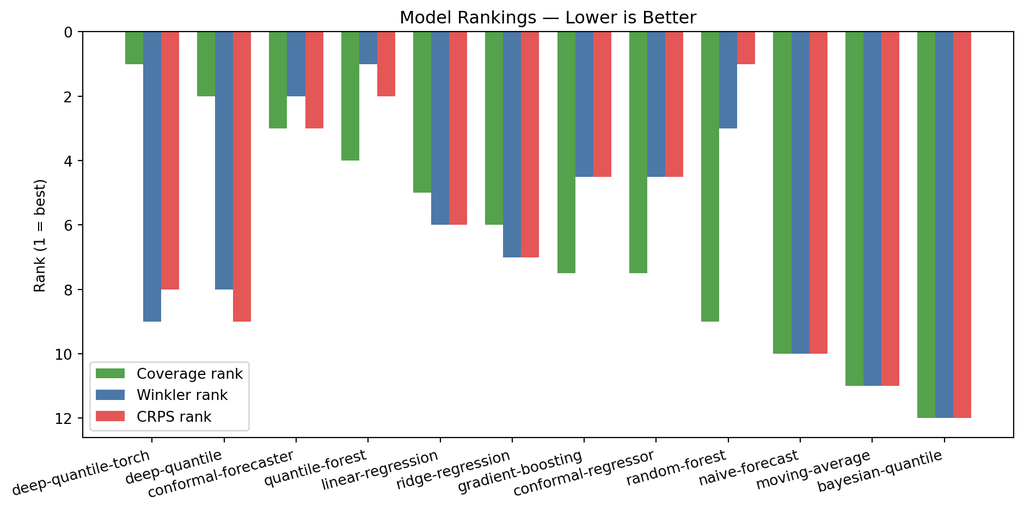

```python
fig, ax = plt.subplots(figsize=(10, 5))
models = ranked["model"].to_numpy()
x = np.arange(len(models))
width = 0.25

ax.bar(x - width, ranked["coverage_rank"].to_numpy(), width, label="Coverage rank", color="#54A24B")
ax.bar(x, ranked["winkler_rank"].to_numpy(), width, label="Winkler rank", color="#4C78A8")
ax.bar(x + width, ranked["crps_rank"].to_numpy(), width, label="CRPS rank", color="#E45756")

ax.set_xticks(x)
ax.set_xticklabels(models, rotation=15, ha="right")
ax.set_ylabel("Rank (1 = best)")
ax.set_title("Model Rankings — Lower is Better")
ax.legend()
ax.invert_yaxis()
plt.tight_layout()
plt.show()
```

### Finding 4: Speed-Quality Tradeoff

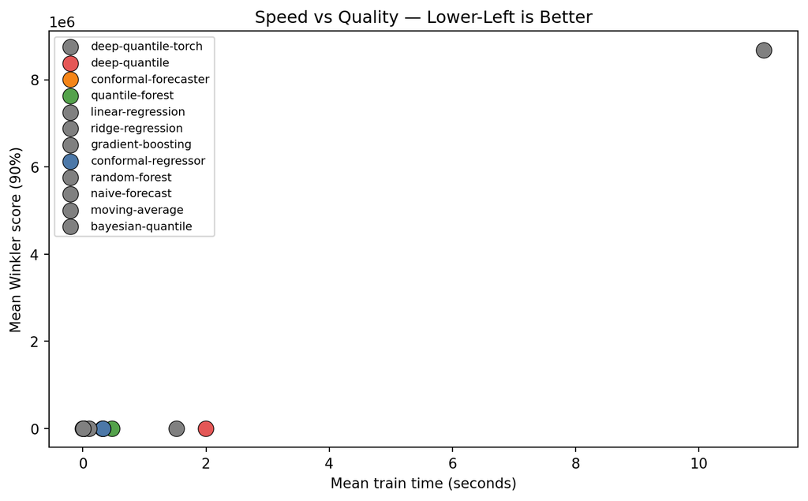

```python
fig, ax = plt.subplots(figsize=(8, 5))
for row in summary.iter_rows(named=True):
    m = row["model"]
    ax.scatter(
        row["mean_train_time"], row["mean_winkler_90"],
        s=120, edgecolors="black", linewidth=0.5,
        label=m, color=colors_map.get(m, "gray"),
    )
ax.set_xlabel("Mean train time (seconds)")
ax.set_ylabel("Mean Winkler score (90%)")
ax.set_title("Speed vs Quality — Lower-Left is Better")
ax.legend(fontsize=8)
plt.tight_layout()
plt.show()
```

## Running Your Own Benchmarks

### Python API

```python
from uncertainty_flow.benchmarking import ModelMatrixCoordinator
from uncertainty_flow.benchmarking.contracts import RunRequest
from uncertainty_flow.benchmarking.registry import default_dataset_registry

frame = default_dataset_registry().load("local_parquet", "weather.parquet")

request = RunRequest(
    dataset={"id": "weather", "provider": "local_parquet", "uri": "weather.parquet", "target": "y"},
    validation={"strategy": "random_holdout", "test_size": 0.2},
    models=({"id": "conformal-forecaster", "provider": "conformal-forecaster"},),
    evaluation={"metrics": ["coverage", "winkler", "crps"]},
    storage={"provider": "local", "root": "data"},
)
result = ModelMatrixCoordinator(storage_root="data").run_with_lock(request, frame)
print(result.model_results[0].metrics)
```

### CLI

```bash
#| label: cli-examples
#| eval: false
uf benchmark --dataset weather --model conformal-regressor,quantile-forest --n-samples 1000

uf list-datasets

uf tune --dataset weather --model quantile-forest
```

### Output Schema (`PipelineRunResult.model_dump_json()`)

```json
{
  "manifest": {},
  "verification": {},
  "artifacts": [],
  "model_results": []
}
```

### Extending Benchmarks

- Stable built-in benchmark names are registered in `registry.py` and include the retained package and baseline providers.
- Prefer a typed provider registration with parameter validation and explicit optional-dependency behavior.
- Persist model outputs through the coordinator; do not add a second standalone execution path.

## Recommendations

| Scenario | Recommended Model | Why |
| --- | --- | --- |
| First time, tabular data | `ConformalRegressor` | Guaranteed coverage, simple API |
| Time series, stationary | `ConformalForecaster` | Temporal awareness, guaranteed coverage |
| Time series, distribution shift | `AdaptiveConformalForecaster` | ACI adapts intervals automatically |
| Need sharpest intervals | `QuantileForestForecaster` | Native quantile predictions, empirically sharp |
| Cost-sensitive decisions | `ConformalRiskControl` | Optimizes for your cost function, not just coverage |
| Multi-class classification | `ConformalClassifier` | APS prediction sets with guaranteed coverage |
| High-dimensional / complex | `DeepQuantileNet` | MLP can capture nonlinear patterns |

## Key Takeaways

- **Start with `ConformalRegressor`** — guaranteed coverage with any sklearn model
- **Benchmark on your own data** — results vary by dataset; no single best model
- **Use the pipeline lifecycle vocabulary** when extending orchestration and adapters
- **Coverage ≠ quality** — also look at Winkler score (sharpness) and CRPS